# R Exercises - Cognitive Psychology

Download data files

This exercise is based on data from a PhD student in cognitive psychology. In his work, this student collects response times (RT) to two simultaneous tasks, and then he has to analyse the response times.

- At $t_0$, the stimulus S1 is triggered
- At $t_1=t_0 + SOA$, the stimulus S2 is triggered (SOA is the time between the 2 stimuli)
- At $t_2=t_0 + RT1$, the subject responds to stimulus S1
- At $t_3=t_1 + RT2$, the subject responds to stimulus S2

The inter-response interval (IRI) is defined as the time difference between $t_3$ and $t_2$, thus $IRI=SOA+RT2-RT1$. Negatives IRI therefore mean that the response to S2 is emitted before the response to S1.

For theoretical reasons, one can consider that if $SOA=1500$ ms, both stimulis are answered independently. One can thus use the RT1 and RT2 values for SOA=1500 ms to estimate the IRI in the case of independent responses to the stimuli.

# Data wrangling

- Download the datafiles archive and unzip it, then create a R project in this folder in Rstudio.
- Load the `tidyverse` and `patchwork` packages:
- Load the .csv file in the `Data` folder and save it into `raw_data`. Look into the help of `read_csv()` to help you get rid of the error.
- Using successive **pipe operations**, we will now create a `dataclean` table from `raw_data`, where we:
  - **Filter** `raw_data` so that `Procedure[Trial]` is only equal to `"EssaisDT"`
  - **Mutate** the table by adding a column `IRI` containing `SOAdur + S2Visuel.RT - S1Audio.RT`
  - **Filter** the table so that some extreme values are excluded:
    - `S1Audio.RT` is smaller or equal to 2500 and larger or equal to 100
    - `S2Visuel.RT` is smaller or equal to 2500 and larger or equal to 100
    - `S1Audio.ACC`, `S1response.ACC` and `S2Visuel.ACC` are equal to 1
- Let’s compute the simulated values in the case the responses to the stimuli are independent, *i.e.* using SOA=1500ms, and save it into a tibble called `IRI_sim`. Using successive pipe operations and starting from `dataclean`:
  - **Filter** rows so that `SOAdur` is equal to 1500
  - Delete the `SOAdur` and `IRI` columns
  - **Mutate** the table to add 3 columns `IRI_sim_xx`, where `xx`=15, 65 or 250 and `IRI_sim_xx = xx + S2Visuel.RT - S1Audio.RT`.
  - Using `pivot_longer()` and the options `names_prefix = "IRI_sim_", names_to = "SOAdur", values_to = "IRI_sim"`, pivot the columns containing `"IRI_sim_"` into a long table (you need to add the option to select the corresponding columns).
- We want now to get the averaged `IRI` per subject and per SOA, and its standard deviation. Using `group_by()` and `summarise()`, store the mean and standard deviation of `IRI` in a table called `stats_obs`, starting from `dataclean`. It should look like this:

```
# A tibble: 24 × 4
# Groups:   Subject [6]
   Subject SOAdur    mean    sd
     <dbl>  <dbl>   <dbl> <dbl>
 1       1     15  -64.8   291.
 2       1     65   20.8   297.
 3       1    250  218.    217.
 4       1   1500 1019.    228.
 5       2     15 -159.    193.
 6       2     65 -156.    236.
 7       2    250    4.42  191.
 8       2   1500 1184.    198.
 9       3     15 -289.    207.
10       3     65 -251.    262.
# ℹ 14 more rows
```

- We want to do the same for the 3 simulated IRI.

```
# A tibble: 18 × 4
# Groups:   Subject [6]
   Subject SOAdur   mean    sd
     <dbl> <chr>   <dbl> <dbl>
 1       1 15     -466.   228.
 2       1 250    -231.   228.
 3       1 65     -416.   228.
 4       2 15     -301.   198.
 5       2 250     -65.9  198.
 6       2 65     -251.   198.
 7       3 15      -99.0  157.
 8       3 250     136.   157.
 9       3 65      -49.0  157.
10       4 15     -168.   214.
11       4 250      66.9  214.
12       4 65     -118.   214.
13       5 15     -367.   249.
14       5 250    -132.   249.
15       5 65     -317.   249.
16       6 15     -313.   161.
17       6 250     -77.9  161.
18       6 65     -263.   161.
```

# Plotting

- We want now to produce a graph showing the histograms of the observed `IRI` column using `ggplot2`.
  - Create a `ggplot` using the `dataclean` dataset
  - Set the aesthetics to `x = IRI`
  - Create the histograms using `geom_histogram()`, with a fill color depending on `SOAdur`
  - Arrange the plots on a grid depending on the `Subject` column using `facet_wrap()`
  - Add a vertical lign marking the average value for each subject using `geom_vline()`. The data for these lines are stored in the `stats_obs` dataset.
  - Play with the theme and other ggplot commands to make the plot look like the one below
    - Try plotting a normalized histogram by [looking up on the Internet how to do this](https://www.google.fr/search?source=hp&ei=g0MLXeGwKNLPgweV04-IBA&q=ggplot+normalized+histogram&oq=ggplot+normalized+histogram)

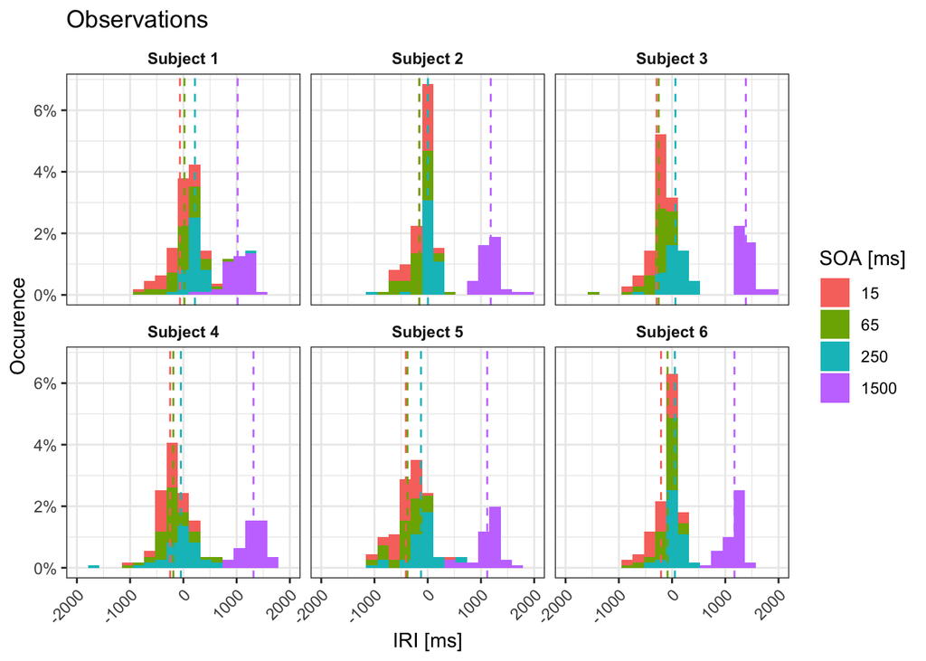

- Let’s do the same for the simulated dataset. It should look like this:

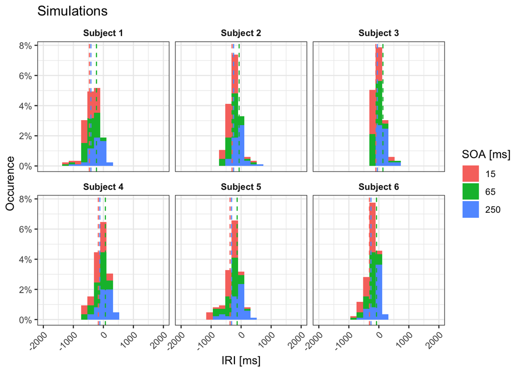